# Risk Factor Analysis

## Outcome Variable

**Outcome Variable:** stunted

## Predictor Variables

**Intervention Variable:** vagbrth

**Adjustment Set:**

- arm
- sex
- W_mage
- meducyrs
- feducyrs
- hhwealth_quart
- W_mhtcm
- single
- brthmon
- W_parity
- delta_W_mage
- delta_meducyrs
- delta_feducyrs
- delta_hhwealth_quart
- delta_W_mhtcm
- delta_single
- delta_brthmon
- delta_W_parity

## Stratifying Variables

The analysis was stratified on these variable(s):

- agecat
- studyid
- country

## Data Summary

| agecat | studyid | country | vagbrth | stunted | n_cell | n |
| --- | --- | --- | --- | --- | --- | --- |
| Birth | ki1000108-CMC-V-BCS-2002 | INDIA | 0 | 0 | 9 | 90 |
| Birth | ki1000108-CMC-V-BCS-2002 | INDIA | 0 | 1 | 2 | 90 |
| Birth | ki1000108-CMC-V-BCS-2002 | INDIA | 1 | 0 | 65 | 90 |
| Birth | ki1000108-CMC-V-BCS-2002 | INDIA | 1 | 1 | 14 | 90 |
| Birth | ki1000108-IRC | INDIA | 0 | 0 | 58 | 388 |
| Birth | ki1000108-IRC | INDIA | 0 | 1 | 10 | 388 |
| Birth | ki1000108-IRC | INDIA | 1 | 0 | 285 | 388 |
| Birth | ki1000108-IRC | INDIA | 1 | 1 | 35 | 388 |
| Birth | ki1017093c-NIH-Crypto | BANGLADESH | 0 | 0 | 1 | 19 |
| Birth | ki1017093c-NIH-Crypto | BANGLADESH | 0 | 1 | 0 | 19 |
| Birth | ki1017093c-NIH-Crypto | BANGLADESH | 1 | 0 | 15 | 19 |
| Birth | ki1017093c-NIH-Crypto | BANGLADESH | 1 | 1 | 3 | 19 |
| Birth | ki1119695-PROBIT | BELARUS | 0 | 0 | 1594 | 13884 |
| Birth | ki1119695-PROBIT | BELARUS | 0 | 1 | 3 | 13884 |
| Birth | ki1119695-PROBIT | BELARUS | 1 | 0 | 12257 | 13884 |
| Birth | ki1119695-PROBIT | BELARUS | 1 | 1 | 30 | 13884 |
| Birth | ki1126311-ZVITAMBO | ZIMBABWE | 0 | 0 | 1073 | 13716 |
| Birth | ki1126311-ZVITAMBO | ZIMBABWE | 0 | 1 | 89 | 13716 |
| Birth | ki1126311-ZVITAMBO | ZIMBABWE | 1 | 0 | 11233 | 13716 |
| Birth | ki1126311-ZVITAMBO | ZIMBABWE | 1 | 1 | 1321 | 13716 |
| Birth | kiGH5241-JiVitA-3 | BANGLADESH | 0 | 0 | 2 | 19586 |
| Birth | kiGH5241-JiVitA-3 | BANGLADESH | 0 | 1 | 1 | 19586 |
| Birth | kiGH5241-JiVitA-3 | BANGLADESH | 1 | 0 | 13256 | 19586 |
| Birth | kiGH5241-JiVitA-3 | BANGLADESH | 1 | 1 | 6327 | 19586 |
| Birth | kiGH5241-JiVitA-4 | BANGLADESH | 0 | 0 | 1 | 822 |
| Birth | kiGH5241-JiVitA-4 | BANGLADESH | 0 | 1 | 0 | 822 |
| Birth | kiGH5241-JiVitA-4 | BANGLADESH | 1 | 0 | 574 | 822 |
| Birth | kiGH5241-JiVitA-4 | BANGLADESH | 1 | 1 | 247 | 822 |
| 6 months | ki1000108-CMC-V-BCS-2002 | INDIA | 0 | 0 | 17 | 369 |
| 6 months | ki1000108-CMC-V-BCS-2002 | INDIA | 0 | 1 | 8 | 369 |

[output cut: 70 more lines]

The following strata were considered:

- agecat: 24 months, studyid: ki1000108-CMC-V-BCS-2002, country: INDIA
- agecat: 24 months, studyid: ki1000108-IRC, country: INDIA
- agecat: 24 months, studyid: ki1017093b-PROVIDE, country: BANGLADESH
- agecat: 24 months, studyid: ki1017093c-NIH-Crypto, country: BANGLADESH
- agecat: 24 months, studyid: ki1066203-TanzaniaChild2, country: TANZANIA, UNITED REPUBLIC OF
- agecat: 24 months, studyid: ki1119695-PROBIT, country: BELARUS
- agecat: 24 months, studyid: ki1126311-ZVITAMBO, country: ZIMBABWE
- agecat: 24 months, studyid: kiGH5241-JiVitA-3, country: BANGLADESH
- agecat: 24 months, studyid: kiGH5241-JiVitA-4, country: BANGLADESH
- agecat: 6 months, studyid: ki1000108-CMC-V-BCS-2002, country: INDIA
- agecat: 6 months, studyid: ki1000108-IRC, country: INDIA
- agecat: 6 months, studyid: ki1017093b-PROVIDE, country: BANGLADESH
- agecat: 6 months, studyid: ki1017093c-NIH-Crypto, country: BANGLADESH
- agecat: 6 months, studyid: ki1066203-TanzaniaChild2, country: TANZANIA, UNITED REPUBLIC OF
- agecat: 6 months, studyid: ki1119695-PROBIT, country: BELARUS
- agecat: 6 months, studyid: ki1126311-ZVITAMBO, country: ZIMBABWE
- agecat: 6 months, studyid: kiGH5241-JiVitA-3, country: BANGLADESH
- agecat: 6 months, studyid: kiGH5241-JiVitA-4, country: BANGLADESH
- agecat: Birth, studyid: ki1000108-CMC-V-BCS-2002, country: INDIA
- agecat: Birth, studyid: ki1000108-IRC, country: INDIA
- agecat: Birth, studyid: ki1017093c-NIH-Crypto, country: BANGLADESH
- agecat: Birth, studyid: ki1119695-PROBIT, country: BELARUS
- agecat: Birth, studyid: ki1126311-ZVITAMBO, country: ZIMBABWE
- agecat: Birth, studyid: kiGH5241-JiVitA-3, country: BANGLADESH
- agecat: Birth, studyid: kiGH5241-JiVitA-4, country: BANGLADESH

### Dropped Strata

Some strata were dropped due to rare outcomes:

- agecat: Birth, studyid: ki1000108-CMC-V-BCS-2002, country: INDIA
- agecat: Birth, studyid: ki1017093c-NIH-Crypto, country: BANGLADESH
- agecat: Birth, studyid: ki1119695-PROBIT, country: BELARUS
- agecat: Birth, studyid: kiGH5241-JiVitA-3, country: BANGLADESH
- agecat: Birth, studyid: kiGH5241-JiVitA-4, country: BANGLADESH
- agecat: 24 months, studyid: ki1066203-TanzaniaChild2, country: TANZANIA, UNITED REPUBLIC OF

## Methods Detail

We’re interested in the causal parameters $E[Y_a]$ for all values of $a \in \mathcal{A}$. These parameters represent the mean outcome if, possibly contrary to fact, we intervened to set all units to have $A=a$. Under the randomization and positivity assumptions, these are identified by the statistical parameters $\psi_a=E_W[E_{Y|A,W}(Y|A=a,W)]$. In addition, we’re interested in the mean of $Y$, $E[Y]$ under no intervention (the observed mean). We will estimate these parameters by using SuperLearner to fit the relevant likelihood factors – $E_{Y|A,W}(Y|A=a,W)$ and $p(A=a|W)$, and then updating our likelihood fit using a joint TMLE.

For unadjusted analyses ($W=\{\}$), initial likelihoods were estimated using Lrnr_glm to estimate the simple $E(Y|A)$ and Lrnr_mean to estimate $p(A)$. For adjusted analyses, a small library containing Lrnr_glmnet, Lrnr_xgboost, and Lrnr_mean was used.

Having estimated these parameters, we will then use the delta method to estimate relative risks and attributable risks relative to a prespecified baseline level of $A$.

# Results Detail

## Results Plots

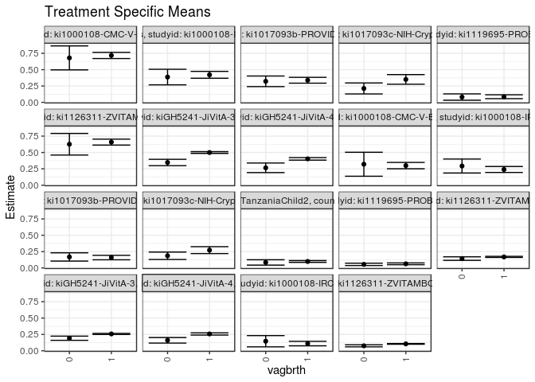

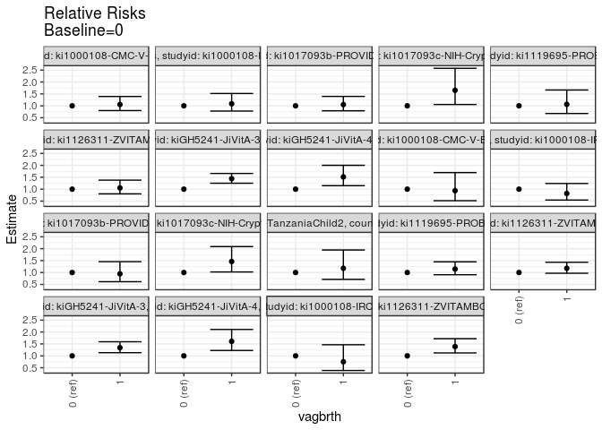

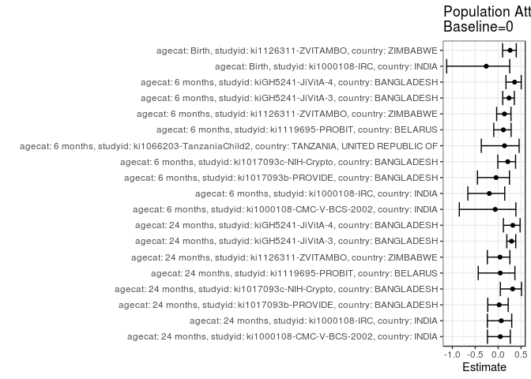

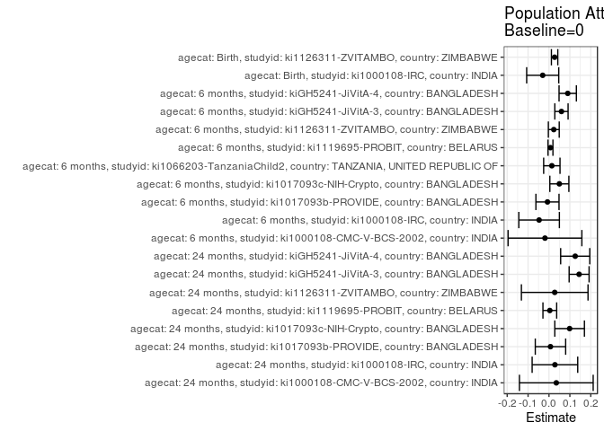

## Results Table

### Parameter: TSM

| agecat | studyid | country | intervention_level | baseline_level | estimate | ci_lower | ci_upper |
| --- | --- | --- | --- | --- | --- | --- | --- |
| Birth | ki1000108-IRC | INDIA | 0 | NA | 0.1460645 | 0.0600003 | 0.2321287 |
| Birth | ki1000108-IRC | INDIA | 1 | NA | 0.1099815 | 0.0756822 | 0.1442808 |
| Birth | ki1126311-ZVITAMBO | ZIMBABWE | 0 | NA | 0.0758880 | 0.0601537 | 0.0916222 |
| Birth | ki1126311-ZVITAMBO | ZIMBABWE | 1 | NA | 0.1054886 | 0.1001097 | 0.1108675 |
| 6 months | ki1000108-CMC-V-BCS-2002 | INDIA | 0 | NA | 0.3200000 | 0.1368964 | 0.5031036 |
| 6 months | ki1000108-CMC-V-BCS-2002 | INDIA | 1 | NA | 0.2994186 | 0.2509538 | 0.3478835 |
| 6 months | ki1000108-IRC | INDIA | 0 | NA | 0.2929497 | 0.1859978 | 0.3999017 |
| 6 months | ki1000108-IRC | INDIA | 1 | NA | 0.2401393 | 0.1945896 | 0.2856890 |
| 6 months | ki1017093b-PROVIDE | BANGLADESH | 0 | NA | 0.1684983 | 0.1052533 | 0.2317433 |
| 6 months | ki1017093b-PROVIDE | BANGLADESH | 1 | NA | 0.1592677 | 0.1253476 | 0.1931879 |
| 6 months | ki1017093c-NIH-Crypto | BANGLADESH | 0 | NA | 0.1866551 | 0.1301777 | 0.2431324 |
| 6 months | ki1017093c-NIH-Crypto | BANGLADESH | 1 | NA | 0.2728908 | 0.2202359 | 0.3255457 |
| 6 months | ki1066203-TanzaniaChild2 | TANZANIA, UNITED REPUBLIC OF | 0 | NA | 0.0845887 | 0.0436536 | 0.1255238 |
| 6 months | ki1066203-TanzaniaChild2 | TANZANIA, UNITED REPUBLIC OF | 1 | NA | 0.0995205 | 0.0857648 | 0.1132762 |
| 6 months | ki1119695-PROBIT | BELARUS | 0 | NA | 0.0555122 | 0.0376825 | 0.0733419 |
| 6 months | ki1119695-PROBIT | BELARUS | 1 | NA | 0.0636233 | 0.0497515 | 0.0774951 |
| 6 months | ki1126311-ZVITAMBO | ZIMBABWE | 0 | NA | 0.1437163 | 0.1167218 | 0.1707107 |
| 6 months | ki1126311-ZVITAMBO | ZIMBABWE | 1 | NA | 0.1692143 | 0.1607297 | 0.1776990 |
| 6 months | kiGH5241-JiVitA-3 | BANGLADESH | 0 | NA | 0.1918540 | 0.1596594 | 0.2240485 |
| 6 months | kiGH5241-JiVitA-3 | BANGLADESH | 1 | NA | 0.2576009 | 0.2492726 | 0.2659293 |
| 6 months | kiGH5241-JiVitA-4 | BANGLADESH | 0 | NA | 0.1600888 | 0.1177818 | 0.2023959 |
| 6 months | kiGH5241-JiVitA-4 | BANGLADESH | 1 | NA | 0.2574288 | 0.2404652 | 0.2743925 |
| 24 months | ki1000108-CMC-V-BCS-2002 | INDIA | 0 | NA | 0.6800000 | 0.4968984 | 0.8631016 |
| 24 months | ki1000108-CMC-V-BCS-2002 | INDIA | 1 | NA | 0.7175793 | 0.6701495 | 0.7650090 |
| 24 months | ki1000108-IRC | INDIA | 0 | NA | 0.3871720 | 0.2680739 | 0.5062701 |
| 24 months | ki1000108-IRC | INDIA | 1 | NA | 0.4214398 | 0.3688336 | 0.4740460 |
| 24 months | ki1017093b-PROVIDE | BANGLADESH | 0 | NA | 0.3221489 | 0.2409100 | 0.4033879 |
| 24 months | ki1017093b-PROVIDE | BANGLADESH | 1 | NA | 0.3384904 | 0.2938057 | 0.3831752 |
| 24 months | ki1017093c-NIH-Crypto | BANGLADESH | 0 | NA | 0.2127872 | 0.1287975 | 0.2967768 |
| 24 months | ki1017093c-NIH-Crypto | BANGLADESH | 1 | NA | 0.3510175 | 0.2773210 | 0.4247139 |
| 24 months | ki1119695-PROBIT | BELARUS | 0 | NA | 0.0812877 | 0.0329216 | 0.1296539 |
| 24 months | ki1119695-PROBIT | BELARUS | 1 | NA | 0.0863269 | 0.0567751 | 0.1158787 |
| 24 months | ki1126311-ZVITAMBO | ZIMBABWE | 0 | NA | 0.6258897 | 0.4607338 | 0.7910456 |
| 24 months | ki1126311-ZVITAMBO | ZIMBABWE | 1 | NA | 0.6585742 | 0.6131663 | 0.7039821 |
| 24 months | kiGH5241-JiVitA-3 | BANGLADESH | 0 | NA | 0.3467692 | 0.2980407 | 0.3954978 |
| 24 months | kiGH5241-JiVitA-3 | BANGLADESH | 1 | NA | 0.4994402 | 0.4860226 | 0.5128577 |
| 24 months | kiGH5241-JiVitA-4 | BANGLADESH | 0 | NA | 0.2655271 | 0.1923806 | 0.3386736 |
| 24 months | kiGH5241-JiVitA-4 | BANGLADESH | 1 | NA | 0.4022960 | 0.3831539 | 0.4214380 |

### Parameter: E(Y)

| agecat | studyid | country | intervention_level | baseline_level | estimate | ci_lower | ci_upper |
| --- | --- | --- | --- | --- | --- | --- | --- |
| Birth | ki1000108-IRC | INDIA | NA | NA | 0.1159794 | 0.0840777 | 0.1478811 |
| Birth | ki1126311-ZVITAMBO | ZIMBABWE | NA | NA | 0.1027997 | 0.0977170 | 0.1078823 |
| 6 months | ki1000108-CMC-V-BCS-2002 | INDIA | NA | NA | 0.3008130 | 0.2539566 | 0.3476694 |
| 6 months | ki1000108-IRC | INDIA | NA | NA | 0.2457002 | 0.2038248 | 0.2875757 |
| 6 months | ki1017093b-PROVIDE | BANGLADESH | NA | NA | 0.1612350 | 0.1313580 | 0.1911120 |
| 6 months | ki1017093c-NIH-Crypto | BANGLADESH | NA | NA | 0.2363239 | 0.1973320 | 0.2753157 |
| 6 months | ki1066203-TanzaniaChild2 | TANZANIA, UNITED REPUBLIC OF | NA | NA | 0.0982544 | 0.0852222 | 0.1112865 |
| 6 months | ki1119695-PROBIT | BELARUS | NA | NA | 0.0626864 | 0.0488489 | 0.0765238 |
| 6 months | ki1126311-ZVITAMBO | ZIMBABWE | NA | NA | 0.1667477 | 0.1586931 | 0.1748023 |
| 6 months | kiGH5241-JiVitA-3 | BANGLADESH | NA | NA | 0.2515539 | 0.2434271 | 0.2596807 |
| 6 months | kiGH5241-JiVitA-4 | BANGLADESH | NA | NA | 0.2497532 | 0.2336426 | 0.2658638 |
| 24 months | ki1000108-CMC-V-BCS-2002 | INDIA | NA | NA | 0.7150538 | 0.6691221 | 0.7609854 |
| 24 months | ki1000108-IRC | INDIA | NA | NA | 0.4156479 | 0.3678270 | 0.4634689 |
| 24 months | ki1017093b-PROVIDE | BANGLADESH | NA | NA | 0.3292894 | 0.2909105 | 0.3676684 |
| 24 months | ki1017093c-NIH-Crypto | BANGLADESH | NA | NA | 0.3115385 | 0.2551365 | 0.3679404 |
| 24 months | ki1119695-PROBIT | BELARUS | NA | NA | 0.0852540 | 0.0554439 | 0.1150642 |
| 24 months | ki1126311-ZVITAMBO | ZIMBABWE | NA | NA | 0.6533333 | 0.6093135 | 0.6973532 |
| 24 months | kiGH5241-JiVitA-3 | BANGLADESH | NA | NA | 0.4909133 | 0.4777756 | 0.5040511 |
| 24 months | kiGH5241-JiVitA-4 | BANGLADESH | NA | NA | 0.3910448 | 0.3723963 | 0.4096932 |

### Parameter: RR

| agecat | studyid | country | intervention_level | baseline_level | estimate | ci_lower | ci_upper |
| --- | --- | --- | --- | --- | --- | --- | --- |
| Birth | ki1000108-IRC | INDIA | 0 | 0 | 1.0000000 | 1.0000000 | 1.000000 |
| Birth | ki1000108-IRC | INDIA | 1 | 0 | 0.7529654 | 0.3864669 | 1.467026 |
| Birth | ki1126311-ZVITAMBO | ZIMBABWE | 0 | 0 | 1.0000000 | 1.0000000 | 1.000000 |
| Birth | ki1126311-ZVITAMBO | ZIMBABWE | 1 | 0 | 1.3900571 | 1.1228027 | 1.720924 |
| 6 months | ki1000108-CMC-V-BCS-2002 | INDIA | 0 | 0 | 1.0000000 | 1.0000000 | 1.000000 |
| 6 months | ki1000108-CMC-V-BCS-2002 | INDIA | 1 | 0 | 0.9356831 | 0.5162674 | 1.695832 |
| 6 months | ki1000108-IRC | INDIA | 0 | 0 | 1.0000000 | 1.0000000 | 1.000000 |
| 6 months | ki1000108-IRC | INDIA | 1 | 0 | 0.8197287 | 0.5429136 | 1.237683 |
| 6 months | ki1017093b-PROVIDE | BANGLADESH | 0 | 0 | 1.0000000 | 1.0000000 | 1.000000 |
| 6 months | ki1017093b-PROVIDE | BANGLADESH | 1 | 0 | 0.9452184 | 0.6142597 | 1.454495 |
| 6 months | ki1017093c-NIH-Crypto | BANGLADESH | 0 | 0 | 1.0000000 | 1.0000000 | 1.000000 |
| 6 months | ki1017093c-NIH-Crypto | BANGLADESH | 1 | 0 | 1.4620061 | 1.0236368 | 2.088106 |
| 6 months | ki1066203-TanzaniaChild2 | TANZANIA, UNITED REPUBLIC OF | 0 | 0 | 1.0000000 | 1.0000000 | 1.000000 |
| 6 months | ki1066203-TanzaniaChild2 | TANZANIA, UNITED REPUBLIC OF | 1 | 0 | 1.1765224 | 0.7116456 | 1.945076 |
| 6 months | ki1119695-PROBIT | BELARUS | 0 | 0 | 1.0000000 | 1.0000000 | 1.000000 |
| 6 months | ki1119695-PROBIT | BELARUS | 1 | 0 | 1.1461136 | 0.9065364 | 1.449006 |
| 6 months | ki1126311-ZVITAMBO | ZIMBABWE | 0 | 0 | 1.0000000 | 1.0000000 | 1.000000 |
| 6 months | ki1126311-ZVITAMBO | ZIMBABWE | 1 | 0 | 1.1774194 | 0.9695773 | 1.429815 |
| 6 months | kiGH5241-JiVitA-3 | BANGLADESH | 0 | 0 | 1.0000000 | 1.0000000 | 1.000000 |
| 6 months | kiGH5241-JiVitA-3 | BANGLADESH | 1 | 0 | 1.3426928 | 1.1326738 | 1.591653 |
| 6 months | kiGH5241-JiVitA-4 | BANGLADESH | 0 | 0 | 1.0000000 | 1.0000000 | 1.000000 |
| 6 months | kiGH5241-JiVitA-4 | BANGLADESH | 1 | 0 | 1.6080376 | 1.2260822 | 2.108982 |
| 24 months | ki1000108-CMC-V-BCS-2002 | INDIA | 0 | 0 | 1.0000000 | 1.0000000 | 1.000000 |
| 24 months | ki1000108-CMC-V-BCS-2002 | INDIA | 1 | 0 | 1.0552636 | 0.7997388 | 1.392431 |
| 24 months | ki1000108-IRC | INDIA | 0 | 0 | 1.0000000 | 1.0000000 | 1.000000 |
| 24 months | ki1000108-IRC | INDIA | 1 | 0 | 1.0885080 | 0.7808720 | 1.517342 |
| 24 months | ki1017093b-PROVIDE | BANGLADESH | 0 | 0 | 1.0000000 | 1.0000000 | 1.000000 |
| 24 months | ki1017093b-PROVIDE | BANGLADESH | 1 | 0 | 1.0507265 | 0.7917923 | 1.394338 |
| 24 months | ki1017093c-NIH-Crypto | BANGLADESH | 0 | 0 | 1.0000000 | 1.0000000 | 1.000000 |
| 24 months | ki1017093c-NIH-Crypto | BANGLADESH | 1 | 0 | 1.6496177 | 1.0564696 | 2.575785 |
| 24 months | ki1119695-PROBIT | BELARUS | 0 | 0 | 1.0000000 | 1.0000000 | 1.000000 |
| 24 months | ki1119695-PROBIT | BELARUS | 1 | 0 | 1.0619925 | 0.6777448 | 1.664090 |
| 24 months | ki1126311-ZVITAMBO | ZIMBABWE | 0 | 0 | 1.0000000 | 1.0000000 | 1.000000 |
| 24 months | ki1126311-ZVITAMBO | ZIMBABWE | 1 | 0 | 1.0522209 | 0.8028709 | 1.379012 |
| 24 months | kiGH5241-JiVitA-3 | BANGLADESH | 0 | 0 | 1.0000000 | 1.0000000 | 1.000000 |
| 24 months | kiGH5241-JiVitA-3 | BANGLADESH | 1 | 0 | 1.4402667 | 1.2497175 | 1.659870 |
| 24 months | kiGH5241-JiVitA-4 | BANGLADESH | 0 | 0 | 1.0000000 | 1.0000000 | 1.000000 |
| 24 months | kiGH5241-JiVitA-4 | BANGLADESH | 1 | 0 | 1.5150842 | 1.1467997 | 2.001640 |

### Parameter: PAR

| agecat | studyid | country | intervention_level | baseline_level | estimate | ci_lower | ci_upper |
| --- | --- | --- | --- | --- | --- | --- | --- |
| Birth | ki1000108-IRC | INDIA | 0 | NA | -0.0300851 | -0.1067880 | 0.0466178 |
| Birth | ki1126311-ZVITAMBO | ZIMBABWE | 0 | NA | 0.0269117 | 0.0116278 | 0.0421955 |
| 6 months | ki1000108-CMC-V-BCS-2002 | INDIA | 0 | NA | -0.0191870 | -0.1957642 | 0.1573902 |
| 6 months | ki1000108-IRC | INDIA | 0 | NA | -0.0472495 | -0.1442939 | 0.0497950 |
| 6 months | ki1017093b-PROVIDE | BANGLADESH | 0 | NA | -0.0072633 | -0.0625386 | 0.0480119 |
| 6 months | ki1017093c-NIH-Crypto | BANGLADESH | 0 | NA | 0.0496688 | 0.0041597 | 0.0951779 |
| 6 months | ki1066203-TanzaniaChild2 | TANZANIA, UNITED REPUBLIC OF | 0 | NA | 0.0136656 | -0.0254640 | 0.0527953 |
| 6 months | ki1119695-PROBIT | BELARUS | 0 | NA | 0.0071742 | -0.0045813 | 0.0189297 |
| 6 months | ki1126311-ZVITAMBO | ZIMBABWE | 0 | NA | 0.0230314 | -0.0029442 | 0.0490070 |
| 6 months | kiGH5241-JiVitA-3 | BANGLADESH | 0 | NA | 0.0596999 | 0.0279686 | 0.0914313 |
| 6 months | kiGH5241-JiVitA-4 | BANGLADESH | 0 | NA | 0.0896644 | 0.0481852 | 0.1311435 |
| 24 months | ki1000108-CMC-V-BCS-2002 | INDIA | 0 | NA | 0.0350538 | -0.1413823 | 0.2114898 |
| 24 months | ki1000108-IRC | INDIA | 0 | NA | 0.0284759 | -0.0805808 | 0.1375327 |
| 24 months | ki1017093b-PROVIDE | BANGLADESH | 0 | NA | 0.0071405 | -0.0655400 | 0.0798210 |
| 24 months | ki1017093c-NIH-Crypto | BANGLADESH | 0 | NA | 0.0987513 | 0.0278930 | 0.1696096 |
| 24 months | ki1119695-PROBIT | BELARUS | 0 | NA | 0.0039663 | -0.0289143 | 0.0368469 |
| 24 months | ki1126311-ZVITAMBO | ZIMBABWE | 0 | NA | 0.0274436 | -0.1319376 | 0.1868249 |
| 24 months | kiGH5241-JiVitA-3 | BANGLADESH | 0 | NA | 0.1441441 | 0.0964239 | 0.1918644 |
| 24 months | kiGH5241-JiVitA-4 | BANGLADESH | 0 | NA | 0.1255176 | 0.0558890 | 0.1951463 |

### Parameter: PAF

| agecat | studyid | country | intervention_level | baseline_level | estimate | ci_lower | ci_upper |
| --- | --- | --- | --- | --- | --- | --- | --- |
| Birth | ki1000108-IRC | INDIA | 0 | NA | -0.2594004 | -1.1232702 | 0.2529970 |
| Birth | ki1126311-ZVITAMBO | ZIMBABWE | 0 | NA | 0.2617877 | 0.0976024 | 0.3961006 |
| 6 months | ki1000108-CMC-V-BCS-2002 | INDIA | 0 | NA | -0.0637838 | -0.8471227 | 0.3873521 |
| 6 months | ki1000108-IRC | INDIA | 0 | NA | -0.1923053 | -0.6609517 | 0.1441100 |
| 6 months | ki1017093b-PROVIDE | BANGLADESH | 0 | NA | -0.0450482 | -0.4507501 | 0.2471992 |
| 6 months | ki1017093c-NIH-Crypto | BANGLADESH | 0 | NA | 0.2101726 | -0.0068773 | 0.3804336 |
| 6 months | ki1066203-TanzaniaChild2 | TANZANIA, UNITED REPUBLIC OF | 0 | NA | 0.1390844 | -0.3672385 | 0.4579031 |
| 6 months | ki1119695-PROBIT | BELARUS | 0 | NA | 0.1144456 | -0.0953900 | 0.2840846 |
| 6 months | ki1126311-ZVITAMBO | ZIMBABWE | 0 | NA | 0.1381214 | -0.0325849 | 0.2806066 |
| 6 months | kiGH5241-JiVitA-3 | BANGLADESH | 0 | NA | 0.2373246 | 0.1005167 | 0.3533246 |
| 6 months | kiGH5241-JiVitA-4 | BANGLADESH | 0 | NA | 0.3590119 | 0.1716167 | 0.5040150 |
| 24 months | ki1000108-CMC-V-BCS-2002 | INDIA | 0 | NA | 0.0490226 | -0.2327896 | 0.2664133 |
| 24 months | ki1000108-IRC | INDIA | 0 | NA | 0.0685098 | -0.2347100 | 0.2972649 |
| 24 months | ki1017093b-PROVIDE | BANGLADESH | 0 | NA | 0.0216846 | -0.2258457 | 0.2192320 |
| 24 months | ki1017093c-NIH-Crypto | BANGLADESH | 0 | NA | 0.3169795 | 0.0484838 | 0.5097120 |
| 24 months | ki1119695-PROBIT | BELARUS | 0 | NA | 0.0465236 | -0.4339254 | 0.3659940 |
| 24 months | ki1126311-ZVITAMBO | ZIMBABWE | 0 | NA | 0.0420056 | -0.2358239 | 0.2573753 |
| 24 months | kiGH5241-JiVitA-3 | BANGLADESH | 0 | NA | 0.2936244 | 0.1895886 | 0.3843046 |
| 24 months | kiGH5241-JiVitA-4 | BANGLADESH | 0 | NA | 0.3209802 | 0.1153622 | 0.4788061 |